# Quantitative methods 2: Data analysis

SKOC39: Introduction to research methods  
and academic writing

nils.holmberg@isk.lu.se

## Quantitative methods

- 9. Experiments and  
     Threats to Validity
- 10. Survey Research,  
      Questionnaire
- 11. Quantitative  
      Content Analysis

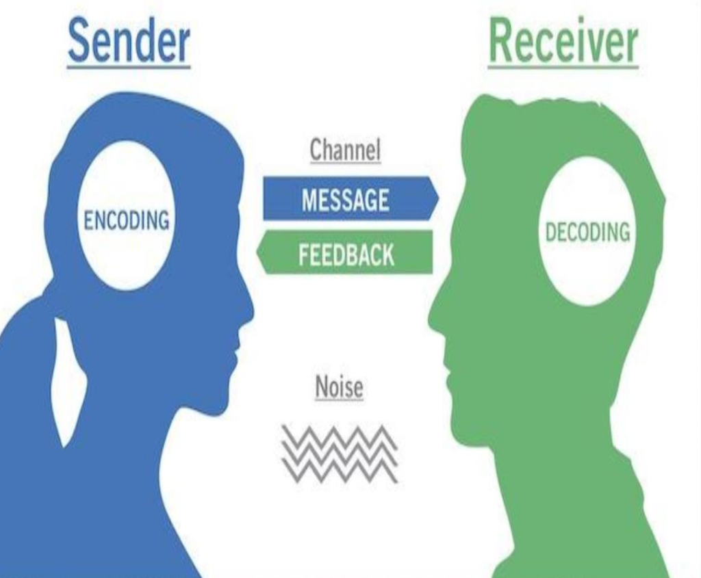

## Course literature

[figure not shown]

Boyle and Schmierbach (2015)

[figure not shown]

Boyle and Schmierbach (2019)

## Lectures and workshops

Data collection (nov 12)

- 5. Concept Explication and Measurement
- 6. Reliability and Validity
- 7. Effective Measurement
- 8. Sampling
- 11. Content Analysis

Exam question 1

Data analysis (nov 26)

- 9. Experiments and Threats to Validity
- 10. Survey Research
- 14. Descriptive Statistics
- 15. Inferential Statistics
- 16. Multivariate Statistics

Exam question 2

## 9. Experiments and Threats to Validity

- Random Assignment (p. 225)
- Between-Subjects Design (p. 227)
- Within-Subjects Design (p. 228)
- Treatment Groups (p. 233)
- Stimulus (p. 233)
- Control Group (p. 238)

## Random Assignment (p. 225)

#### 9. Experiments and Threats to Validity

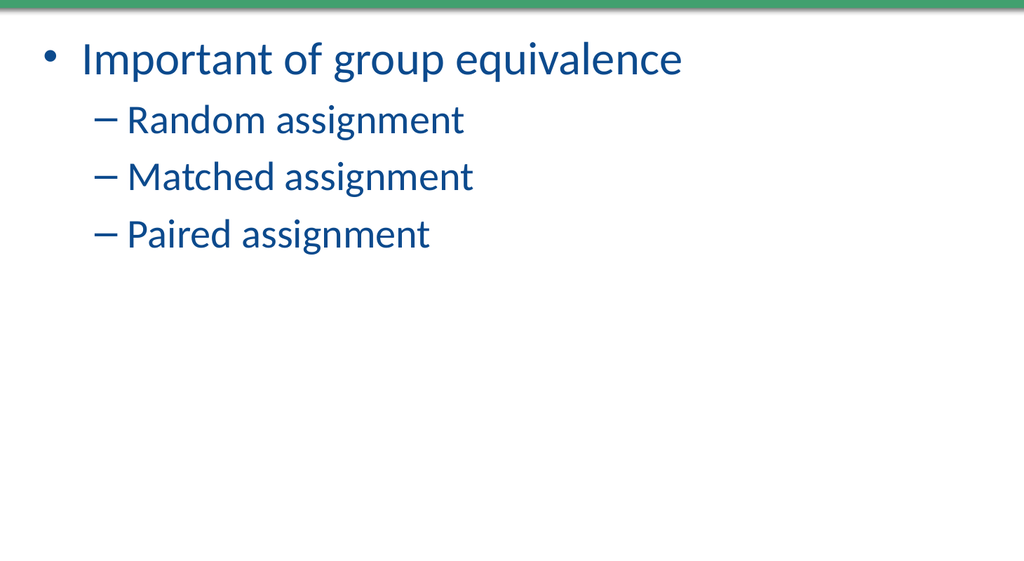

## Between-Subjects Design (p. 227)

#### 9. Experiments and Threats to Validity

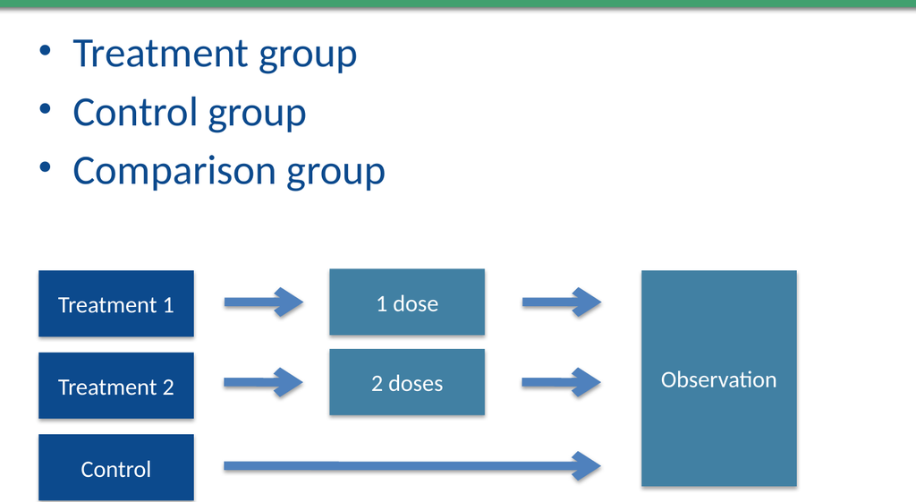

## Within-Subjects Design (p. 228)

#### 9. Experiments and Threats to Validity

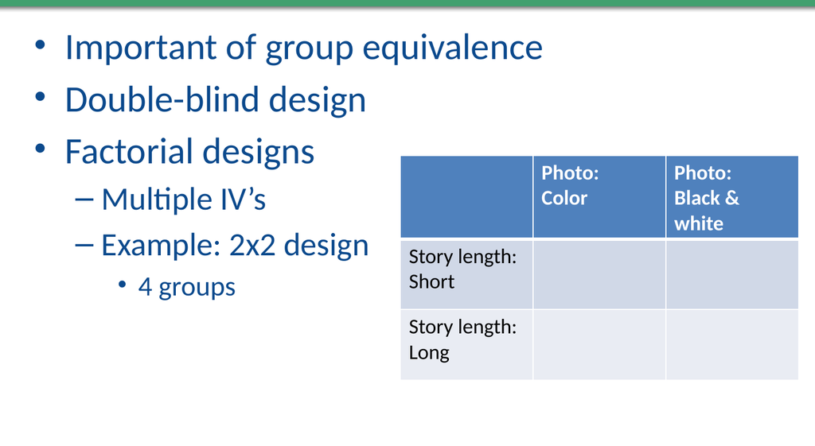

## Treatment Groups (p. 233)

#### 9. Experiments and Threats to Validity

[video not shown]

## Stimulus (p. 233)

#### 9. Experiments and Threats to Validity

- **Hawthorne effect**: Changes in participants’ behavior occur simply because they are aware they are being observed.
- **History effect**: External events during the experiment influence participants’ responses or outcomes.
- **Interparticipant bias**: Participants influence each other in ways that affect the results, compromising validity.
- **Maturation**: Natural changes in participants over time (e.g., aging, learning) affect the dependent variable independently of the experiment.
- **Mortality**: Loss of participants from a study, potentially leading to biased results if dropouts are non-random.
- **Regression toward the mean**: Extreme initial measurements naturally tend to move closer to the average on subsequent measurements.
- **Ceiling and floor effects**: When measurements are constrained by an upper (ceiling) or lower (floor) limit, reducing the ability to detect changes or differences.

## Control Group (p. 238)

#### 9. Experiments and Threats to Validity

## 10. Survey Research

- Polls (p. 262)
- Cross-Sectional Design (p. 264)
- Internet Survey (p. 273)

## Polls (p. 262)

#### 10. Survey Research

- **Definition**: Polls are structured sets of questions designed to gather opinions or attitudes from a group of individuals.
- **Explanation**: Often used in political, social, or market research to measure public opinion or trends.
- **Key Features**:
  - Representative sampling is critical for accuracy.
  - Questions must be clear and unbiased to avoid leading responses.
- **Examples**:
  - Pre-election polls predicting voter preferences.
  - Customer satisfaction surveys after a product purchase.
  - Community sentiment on policy changes (e.g., local development projects).

## Cross-Sectional Design (p. 264)

#### 10. Survey Research

- **Definition**: A research design that collects data from participants at a single point in time to explore relationships or differences between variables.
- **Explanation**:
  - Useful for identifying associations, not causation.
  - Efficient and cost-effective but may miss changes over time.
- **Key Features**:
  - Snapshot approach provides immediate insights.
  - Vulnerable to confounding variables that cannot be tracked over time.
- **Examples**:
  - A survey measuring dietary habits and BMI in different age groups.
  - A study examining smartphone usage patterns by income level.
  - Public opinion surveys on climate change conducted within a single week.

## Internet Survey (p. 273)

#### 10. Survey Research

- **Definition**: Surveys distributed and completed online, typically via email, websites, or social media platforms.
- **Explanation**:
  - Allows for rapid data collection across large, diverse populations.
  - May introduce biases such as non-representative sampling or self-selection.
- **Key Features**:
  - Cost-effective and time-efficient.
  - Flexible design options, including multimedia integration.
- **Examples**:
  - Employee satisfaction surveys distributed through internal company portals.
  - Social media polls gauging interest in new products.
  - Academic research surveys hosted on platforms like Qualtrics or Google Forms.

## 14. Descriptive Statistics

- Mean, Central Tendency (p. 361)
- Median, Central Tendency (p. 362)
- Mode, Central Tendency (p. 364)
- Range, Dispersion (p. 366)
- Variance, Dispersion (p. 366)
- Standard Deviation, Dispersion (p. 368)
- Histogram, Distribution (p. 372)
- Normal Distribution (p. 373)
- Outliers, Distribution (p. 376)

## Mean, Central Tendency (p. 361)

#### 14. Descriptive Statistics

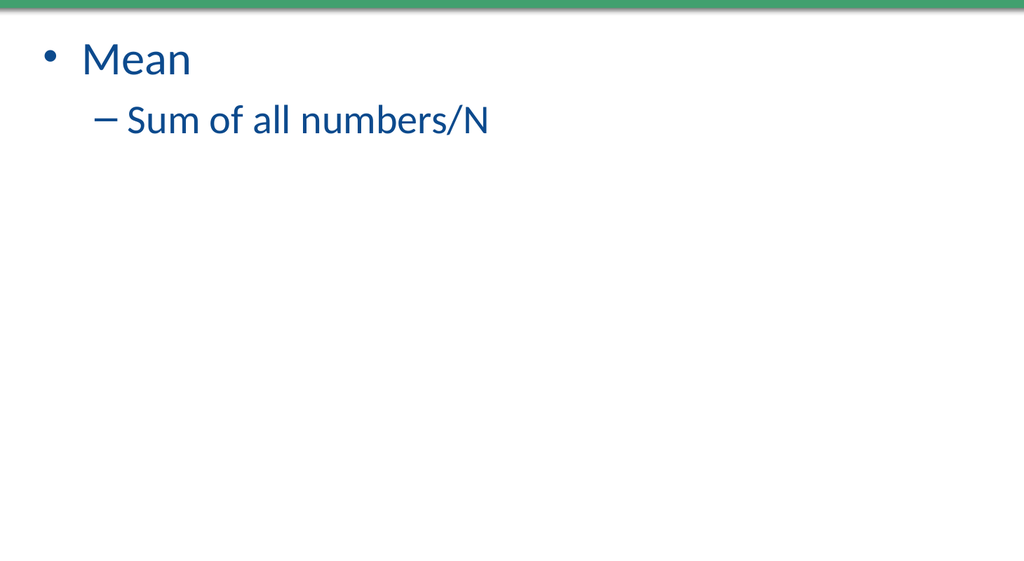

## Median, Central Tendency (p. 362)

#### 14. Descriptive Statistics

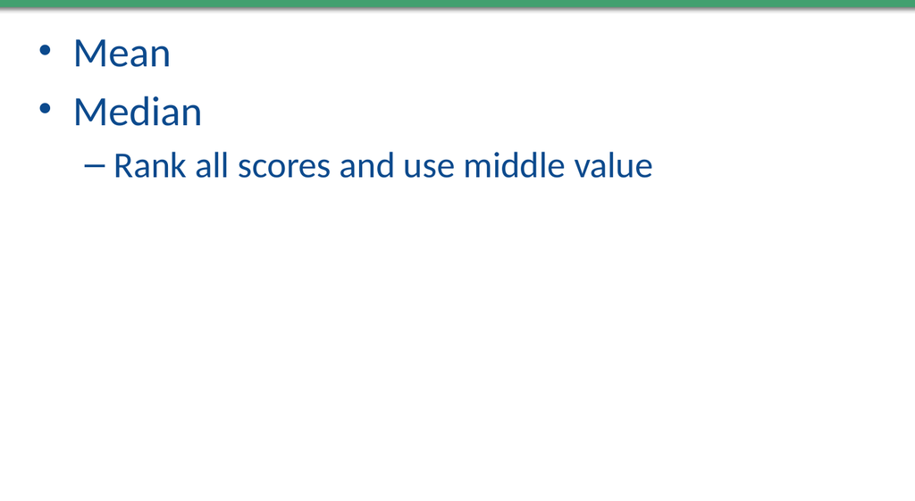

## Mode, Central Tendency (p. 364)

#### 14. Descriptive Statistics

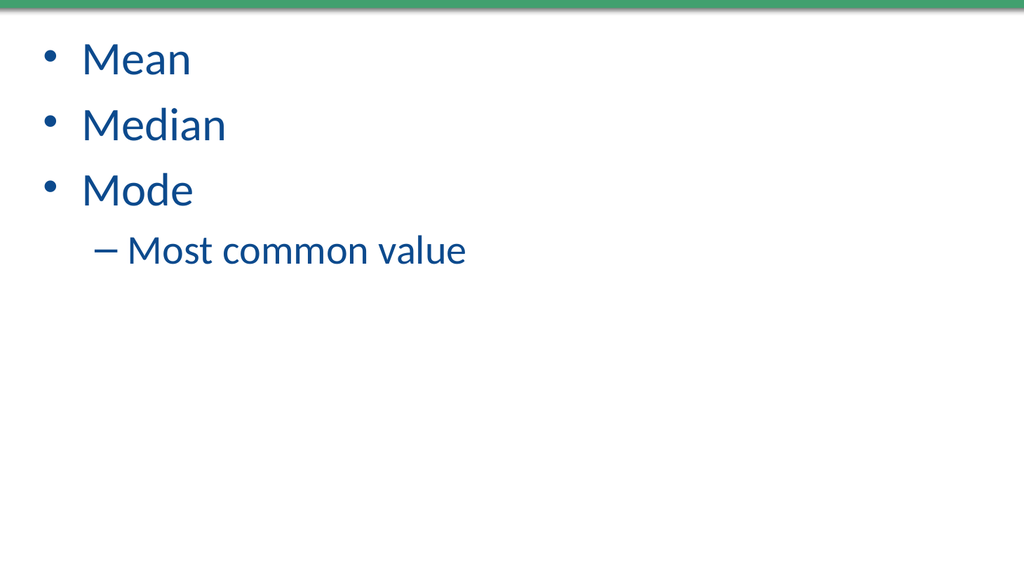

## Range, Dispersion (p. 366)

#### 14. Descriptive Statistics

[figure not shown]

## Variance, Dispersion (p. 366)

#### 14. Descriptive Statistics

[figure not shown]

## Standard Deviation, Dispersion (p. 368)

#### 14. Descriptive Statistics

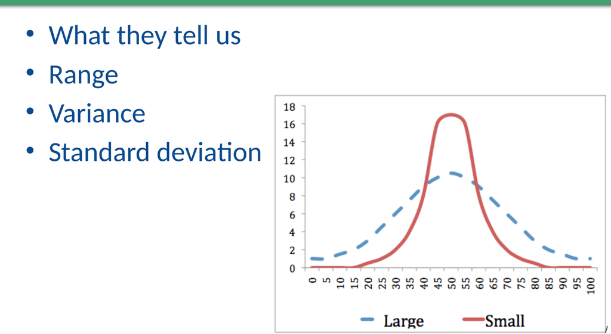

## Histogram, Distribution (p. 372)

#### 14. Descriptive Statistics

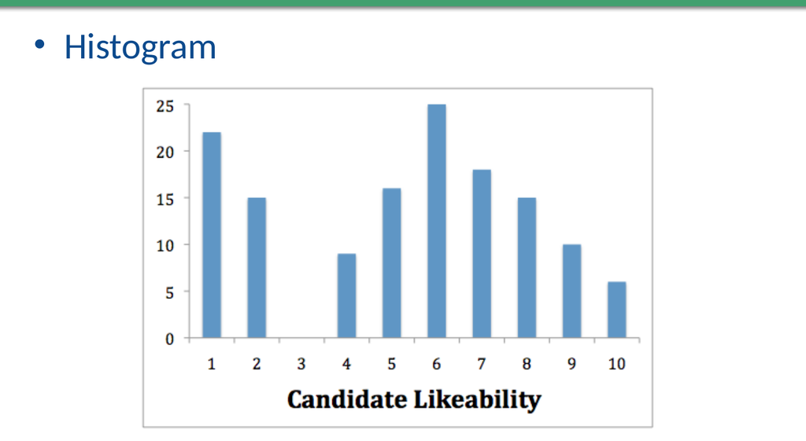

## Normal Distribution (p. 373)

#### 14. Descriptive Statistics

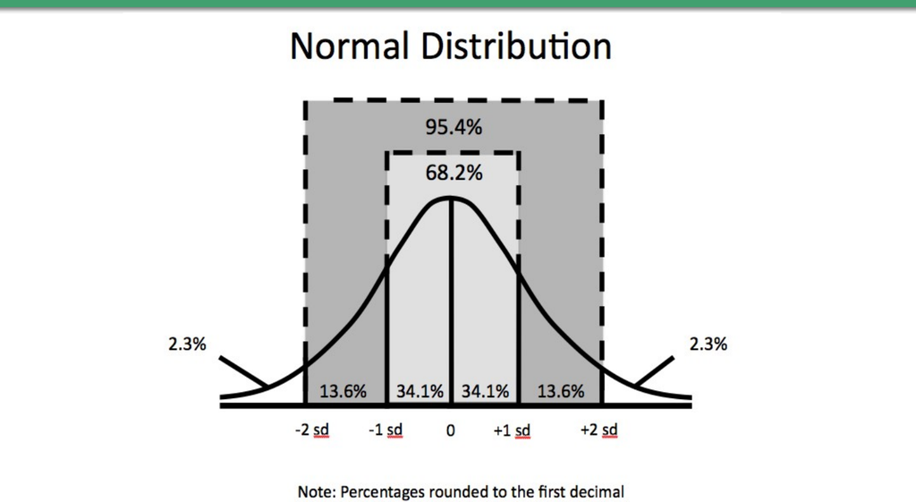

## Outliers, Distribution (p. 376)

#### 14. Descriptive Statistics

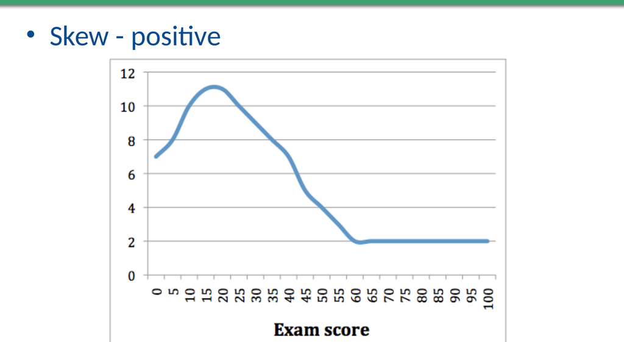

## 15. Principles of Inferential Statistics

- Null Hypothesis (p. 392)
- Statistical Significance (p. 395)
- Type I Error (p. 397)
- Type II Error (p. 400)
- Variance Explained (p. 404)
- Bivariate Analysis (p. 405)
- Chi-Square (p. 406)
- One-Way ANOVA (p. 411)
- Correlation (Pearson’s r) (p. 413)
- Linearity (p. 415)

## Sample Data, Job Performance

|  | Job_Performance | Job_Satisfaction | Job_Satisfaction_Binary | Organizational_Support_Binary |
| --- | --- | --- | --- | --- |
| 0 | 9.628835 | 5.993428 | High | Low |
| 1 | 10.569730 | 4.723471 | Low | Low |
| 2 | 13.719371 | 6.295377 | High | Low |
| 3 | 14.809352 | 8.046060 | High | Low |
| 4 | 8.885464 | 4.531693 | Low | Low |
| 5 | 10.519744 | 4.531726 | Low | High |
| 6 | 24.005538 | 8.158426 | High | High |
| 7 | 15.031775 | 6.534869 | High | High |
| 8 | 10.814470 | 4.061051 | Low | High |
| 9 | 16.893897 | 6.085120 | High | Low |

## Null Hypothesis (p. 392)

#### 15. Principles of Inferential Statistics

- Assumes no effect or relationship exists (e.g., **Job Satisfaction** has no effect on **Job Performance**).
- Provides a baseline for statistical testing.
- Example: Test if **Job Satisfaction Binary** impacts **Job Performance**.
- Rejecting the null suggests the effect is likely real.

## Statistical Significance (p. 395)

#### 15. Principles of Inferential Statistics

- Indicates observed results are unlikely due to chance (e.g., p < 0.05).
- Determines whether effects are statistically reliable.
- Example: Chi-square test for **Job Satisfaction Binary** and **Job Performance**.
- Significance ≠ practical importance.

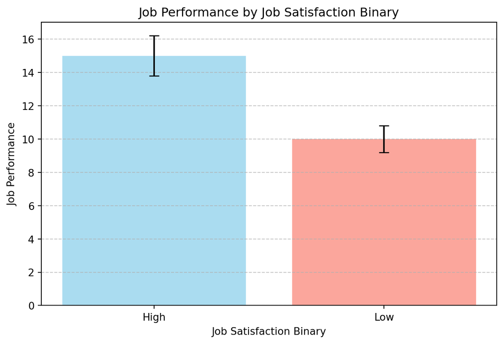

## Type I Error (p. 397)

#### 15. Principles of Inferential Statistics

- Occurs when rejecting a true null hypothesis (false positive).
- Example: Concluding **Organizational Support Binary** affects **Job Performance** when it does not.
- Controlled by setting a significance level (e.g., α = 0.05).
- Use robust methods to minimize Type I errors.

## Type II Error (p. 400)

#### 15. Principles of Inferential Statistics

- Failing to reject a false null hypothesis (false negative).
- Example: Missing a real effect of **Job Satisfaction Binary** on **Job Performance**.
- Reduced by increasing sample size or statistical power.
- Balance Type I and II error risks in study design.

## Variance Explained (p. 404)

#### 15. Principles of Inferential Statistics

- Proportion of variability in the dependent variable explained by the independent variable(s).
- Example: **Job Satisfaction** explains 45% of variance in **Job Performance**.
- R² indicates the strength of the relationship.
- Higher variance explained = better model fit.

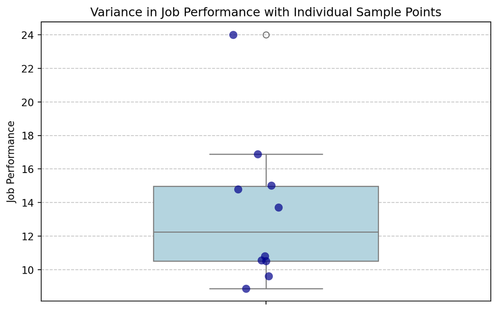

## Bivariate Analysis (p. 405)

#### 15. Principles of Inferential Statistics

- Examines the relationship between two variables (e.g., **Job Satisfaction** and **Job Performance**).
- Methods: scatterplots, Pearson’s r, and simple regression.
- Example: Positive correlation between **Job Satisfaction** and **Job Performance**.
- Helps assess significant associations before multivariate analysis.

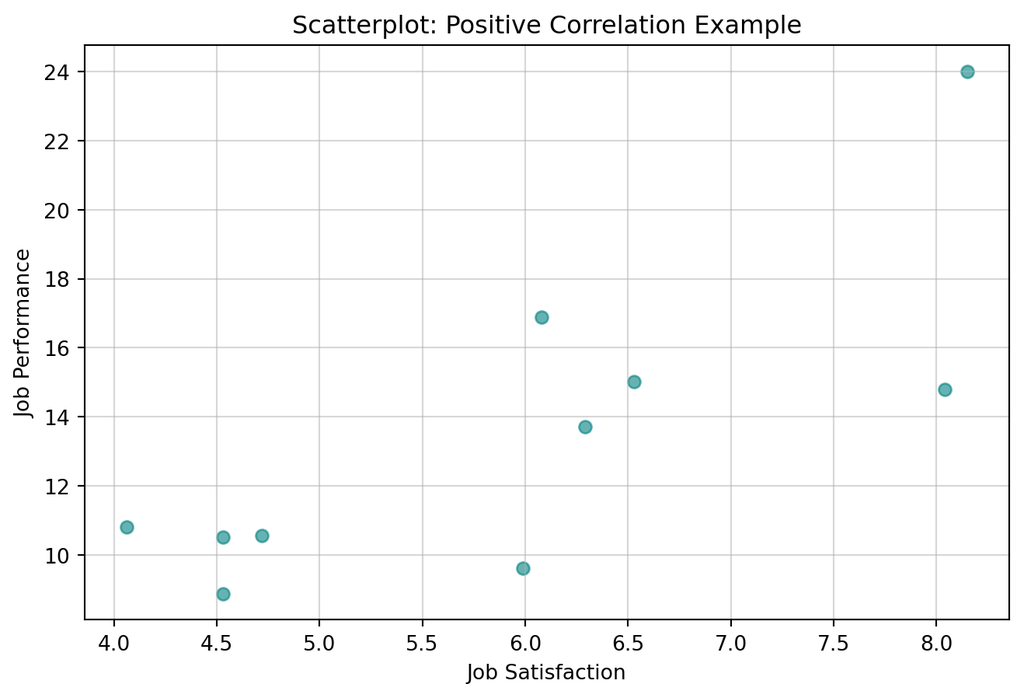

## Chi-Square (p. 406)

#### 15. Principles of Inferential Statistics

- Tests independence between categorical variables.
- Example: Relationship between **Job Satisfaction Binary** and **Organizational Support Binary**.
- Compares observed vs. expected frequencies.
- Suitable for contingency tables with large enough samples.

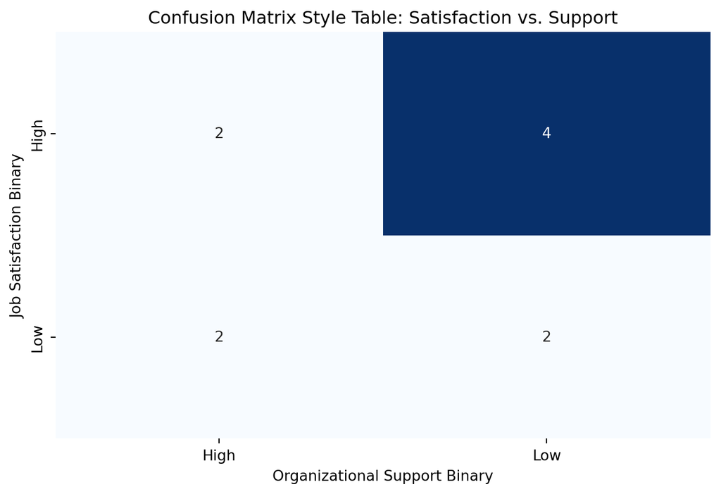

## One-Way ANOVA (p. 411)

#### 15. Principles of Inferential Statistics

- Tests if means of a continuous variable differ across groups of a categorical variable.
- Example: Does **Job Performance** differ by **Job Satisfaction Binary**?
- Outputs F-statistic and p-value to assess group differences.
- Use post-hoc tests for specific group comparisons.

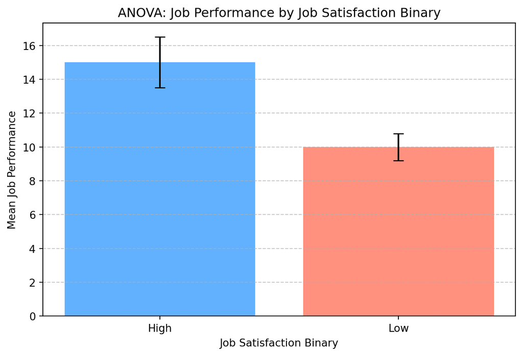

## Correlation (Pearson’s r) (p. 413)

#### 15. Principles of Inferential Statistics

- Measures the linear relationship between two continuous variables.
- Example: Correlation between **Job Satisfaction** and **Job Performance**.
- r near 1/-1 = strong positive/negative correlation.
- Assumes linearity and no significant outliers.

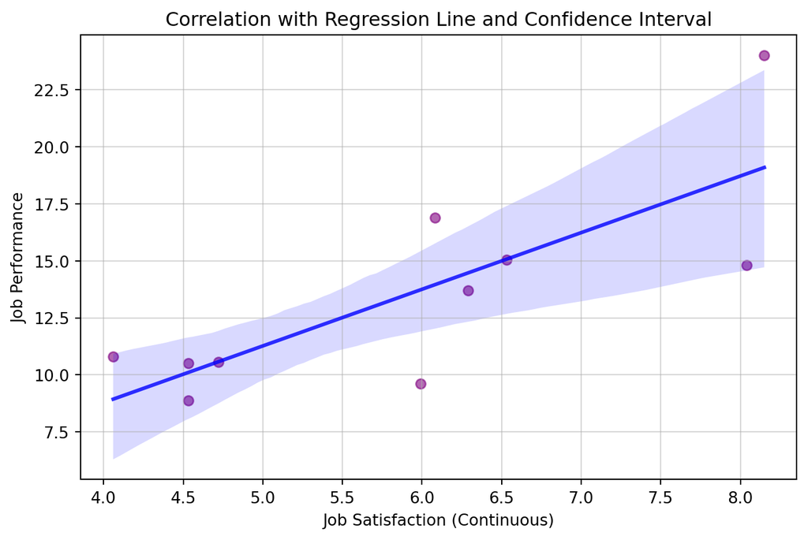

## Linearity (p. 415)

#### 15. Principles of Inferential Statistics

- Assumes a straight-line relationship between variables.
- Example: **Job Satisfaction** and **Job Performance** should appear linear.
- Non-linearity can bias results; check scatterplots.
- Use transformations or alternative models if needed.

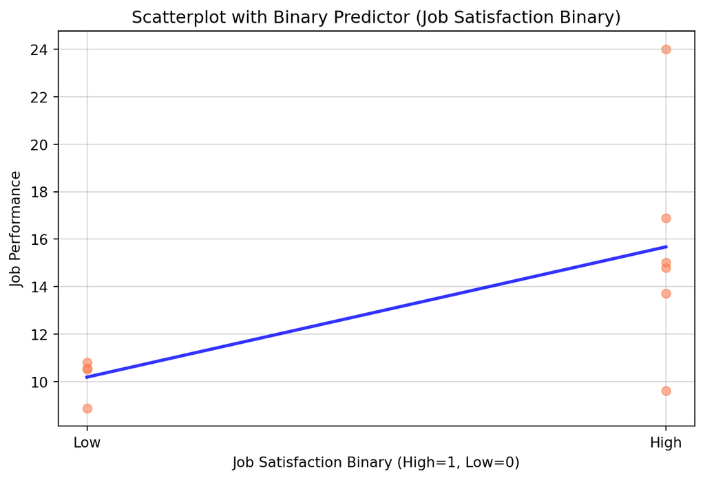

## 16. Multivariate Inferential Statistics

- Statistical Control (p. 428)
- Spuriousness (p. 429)
- Interaction (p. 431)
- ANCOVA (p. 435)
- MANOVA (p. 436)
- Unstandardized Coefficients (p. 442)
- Standardized Coefficients (p. 443)
- R2 (p. 444)
- Logistic Regression (p. 445)
- Odds Ratio (p. 446)
- Statistical Test (p. 447)
- Statistical Analysis (p. 450)

## Statistical Control (p. 428)

#### 16. Multivariate Inferential Statistics

- **Control**: Isolates the effect of an independent variable by holding other variables constant.
- **Example**: Controlling for **Organizational Support Binary** when analyzing **Job Satisfaction**’s effect on **Job Performance**.
- **Spuriousness**: Apparent relationships between variables that arise from a common third variable.
- **Example**: If both **Job Satisfaction** and **Job Performance** correlate with **Organizational Support**, the observed relationship might be spurious.

## Spuriousness (p. 429)

#### 16. Multivariate Inferential Statistics

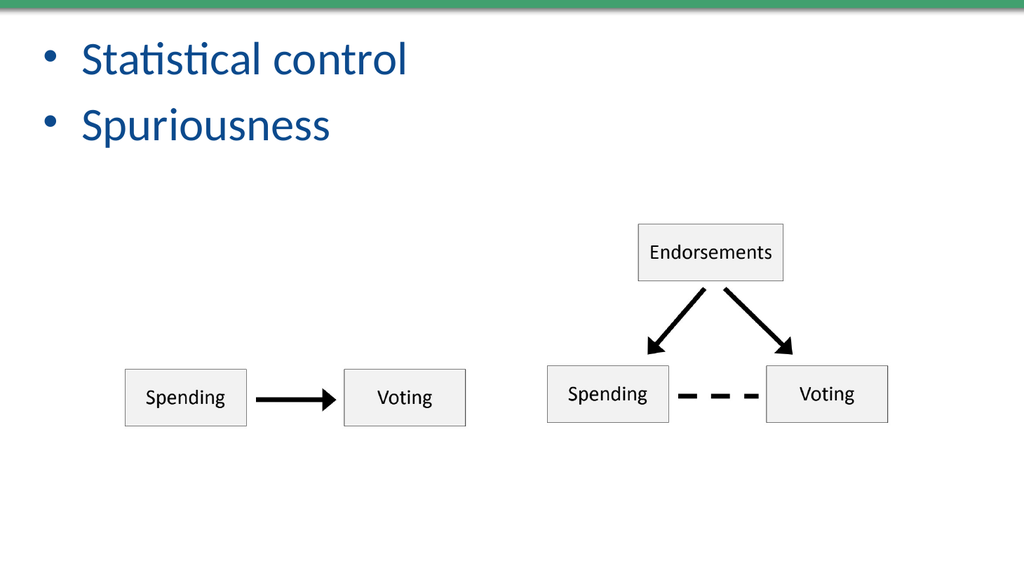

## Interaction (p. 431)

#### 16. Multivariate Inferential Statistics

- **Definition**: Occurs when the effect of one independent variable on the dependent variable changes depending on another variable.
- **Example**: The impact of **Job Satisfaction** on **Job Performance** may differ by **Organizational Support Binary**.
- **Purpose**: Reveals combined effects of predictors, improving model depth.
- **Visualization**: Interaction plots can show differing slopes for groups.

## ANCOVA (p. 435)

#### 16. Multivariate Inferential Statistics

- **Definition**: Combines ANOVA and regression to control for covariates while testing group differences.
- **Example**: Examining **Job Performance** differences by **Job Satisfaction Binary**, controlling for **Organizational Support**.
- **Strength**: Reduces variability from confounders, increasing test sensitivity.
- **Output**: Provides adjusted means and F-statistic for group effects.

## MANOVA (p. 436)

#### 16. Multivariate Inferential Statistics

- **Definition**: Extends ANOVA to analyze multiple dependent variables simultaneously.
- **Example**: Assessing how **Job Satisfaction Binary** affects **Job Performance** and **Organizational Support** together.
- **Purpose**: Detects patterns across variables, reducing Type I error risk.
- **Output**: Reports Wilks’ Lambda for overall model significance.

## Unstandardized Coefficients (p. 442)

#### 16. Multivariate Inferential Statistics

- **Definition**: Reflect the change in the dependent variable for a one-unit change in an independent variable.
- **Example**: A coefficient of 2.3 indicates a 2.3-unit increase in **Job Performance** per unit of **Job Satisfaction**.
- **Usage**: Useful for practical interpretation in original measurement units.
- **Limitation**: Cannot compare effects across variables with different scales.

## Standardized Coefficients (p. 443)

#### 16. Multivariate Inferential Statistics

- **Definition**: Reflect the relative strength of predictors on the dependent variable by standardizing scales.
- **Example**: A standardized coefficient of 0.7 suggests a stronger effect of **Job Satisfaction** than a coefficient of 0.3 for **Organizational Support**.
- **Purpose**: Enables direct comparison of predictor importance.
- **Output**: Expressed as beta coefficients in regression.

## R2 (p. 444)

#### 16. Multivariate Inferential Statistics

- **Definition**: Proportion of variance in the dependent variable explained by the independent variables.
- **Example**: R² = 0.65 means 65% of variability in **Job Performance** is explained by the model.
- **Purpose**: Measures model fit and explanatory power.
- **Limitation**: High R² does not confirm causality or practical importance.

## Logistic Regression (p. 445)

#### 16. Multivariate Inferential Statistics

- **Definition**: Predicts binary outcomes using independent variables.
- **Example**: Predicting **High** or **Low Job Performance** based on **Job Satisfaction Binary**.
- **Output**: Reports coefficients as log odds for each predictor.
- **Purpose**: Handles classification problems effectively.

## Odds Ratio (p. 446)

#### 16. Multivariate Inferential Statistics

- **Definition**: Represents the likelihood of an outcome occurring in one group compared to another.
- **Example**: Odds ratio > 1 indicates **High Satisfaction** increases the odds of **High Performance**.
- **Purpose**: Quantifies the impact of predictors in logistic regression.
- **Usage**: Useful in risk assessment and binary classification models.

## Statistical Test (p. 447)

#### 16. Multivariate Inferential Statistics

- **Definition**: Assesses whether observed data differ significantly from expectations.
- **Example**: A t-test evaluates whether **Job Performance** differs significantly between **High** and **Low Satisfaction** groups.
- **Output**: Provides p-values to determine statistical significance.
- **Purpose**: Validates hypotheses with inferential methods.

## Statistical Analysis (p. 450)

#### 16. Multivariate Inferential Statistics

- **Definition**: Uses mathematical methods to summarize, explore, and infer from data.
- **Example**: Regression analysis examines how **Job Satisfaction** predicts **Job Performance**.
- **Methods**: Includes descriptive, inferential, and multivariate techniques.
- **Goal**: Transforms raw data into actionable insights.

## Next steps

**Workshop 2, dec 2**

- Survey databases, e.g.: https://github.com/cca-cce/osm-cda/raw/refs/heads/main/csv/Job_Performance_Dataset.tsv
- Data analysis software: https://www.jamovi.org/download.html

**References**

Boyle, Michael, and Mike Schmierbach. 2015. *Applied Communication Research Methods: Getting Started as a Researcher*. Routledge.

———. 2019. *Applied Communication Research Methods: Getting Started as a Researcher*. Routledge.

https://canvas.education.lu.se/courses/28874